# L7

# Uncertainty and Randomness (Expectimax)

- Good for explicit randomness, unpredictable opponents, or actions that can fail
- Values should now reflect average-case (expectimax) outcomes, not worst-case (minimax) outcomes
- Expectimax ≙ compute the average scores under optimal play
  - Max nodes as in minimax search
  - Chance nodes are like min nodes, but the outcome is uncertain
  - Calculate their expected utilities ≙ weighted average (expectation) of children

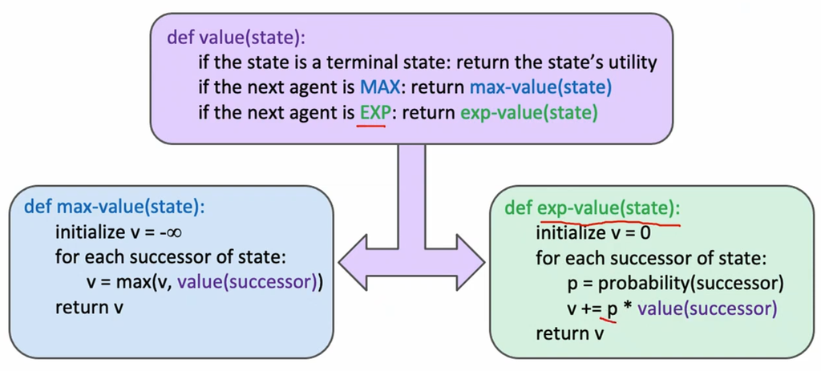

- Cannot prune
- Depth-limitation works
- Expected value of a function of a random variable ≙ the average weighted by the probability distribution over outcomes
- Can be challenging to get the optimal weights for an expectimax model

## Mixed Layer Types

- Expectiminimax
  - Environment is an extra ‘random agent’ player that moves after each min/max agent
  - Each node computes the appropriate combination of its children

# Multi-Agent Utilities

- Minimax
  - Have layers for each player
  - Have to propagate each value for each player up the tree
  - Terminals have utility tuples
  - Each player maximizes its own value

# Difficulties with Search

- Even with alpha-beta pruning and limited depth, large $b$ is an issue ($O(b^{\frac{m}{2}})$)
- Limiting depth requires us to design good evaluation functions
  - Not a general-purpose method: need to design new evaluation function for each new problem
  - Bad evaluation function may lead to inefficient or biased solutions
  - The trend in AI is to prefer general method and less human tweaking

## Monte Carlo Tree Search (MCTS)

- Evaluation by rollouts: estimate value of a state by playing many games from this state by taking random actions (or some other fast policy) and count wins and losses
  - Allocate more rollouts to promising or uncertain nodes
- Selective search: explore parts of the tree that will help improve the decision at the root, regardless of depth

### Upper Confidence Bound (UCB) Heuristic

$$\left.\mathrm{UCB1(n)=\frac{U(n)}{N(n)}+C\times\sqrt{\frac{{\log}(n)(\mathrm{parent(n)})}{N(n)}}}\;\right\vert\;_{\begin{array}{l}
C\;\hat{=}\;{\text{parameter we chose to trade off between two terms}}
\\
N(n)\;\hat{=}\;{\text{number of rollouts from node}\,n} \\
U(n)\;\hat{=}\;{\text{total utility of rollouts for player
of}\,\mathrm{parent(n)}}
\end{array}}$$
- The total utility of rollouts ≙ the number of wins - Have to keep track of both $N$ and $U$ for each node - Combines ‘promising’ and ‘uncertain’

#### Monte Carlo Tree Search (MCTS) Algorithm

- Repeat until end of time:
  1. Selection: recursively apply UCB to choose a path down and leaf node $n$
  2. Expansion: add a new child $c$ to $n$
  3. Simulation: run a rollout from $c$
  4. Back-propagation: update $U$ and $N$ counts from $c$ back up to the root
- Choose the action leading to the child with highest $N$
- Most common tool for solving hard search problems
- Time complexity independent of $b$ and $m$
- No need to design evaluation functions (general-purpose and easy to use)
- Solution quality depends on number of rollouts $N$
  - Theorem: as $N\to{\infty}$, MCTS selects the minimax move
- Maps well to parallel hardware